# Spatial Analysis

Where delays accumulate: top delay stops, district breakdown and line comparison.

## Setup

```python
from zh_tram_flow.notebook import *
import zh_tram_flow.analytics.spatial as an

TRAIN, TEST, lf, lf_all, lf_delay, lf_clean = setup_analysis("03_analysis_4-spatial")

# lf_all   — train + test features combined (all years)
# lf_delay — lf_all filtered: canceled == False
# lf_clean — analysis-ready: canceled=False · stop_sequence>1 · no Linie E/L50/L51
#             departure_delay / delay_delta masked to NaN for Nov 14–Dec 23 2025
#             (is_anomal flag added for transparency)
%load_ext autoreload
%autoreload 2
```

```
✓  wgnd theme activated (matplotlib · seaborn)
```

```
2026-06-11 14:52:36  INFO      project  03_analysis_4-spatial started
```

```
The autoreload extension is already loaded. To reload it, use:
  %reload_ext autoreload
```

## Top Delay Stops

Stops with highest average `arrival_delay` — potential bottleneck candidates.

```
───  TOP DELAY STOPS  ────────────────────────────────────────
```

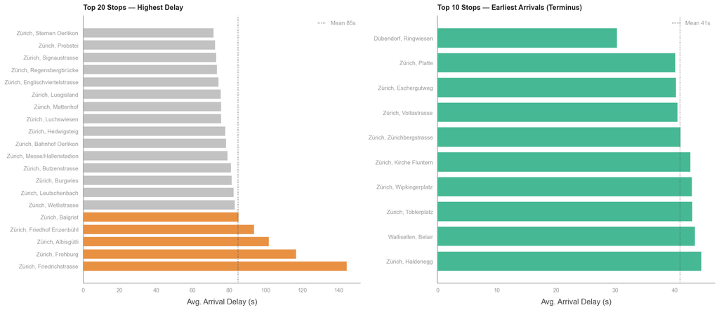

```
Top 10 Tabelle
```

|  | Halt | Avg. Delay (s) | OTP | n Stops |
| --- | --- | --- | --- | --- |
| 0 | Zürich, Friedrichstrasse | 144.60 | 0.60 | 14375 |
| 1 | Zürich, Frohburg | 116.70 | 0.70 | 14390 |
| 2 | Zürich, Albisgütli | 101.80 | 0.70 | 13992 |
| 3 | Zürich, Friedhof Enzenbühl | 93.80 | 0.70 | 292204 |
| 4 | Zürich, Balgrist | 85.20 | 0.80 | 292940 |
| 5 | Zürich, Wetlistrasse | 83.30 | 0.80 | 291455 |
| 6 | Zürich, Leutschenbach | 82.70 | 0.80 | 546617 |
| 7 | Zürich, Burgwies | 81.50 | 0.80 | 290075 |
| 8 | Zürich, Butzenstrasse | 81.00 | 0.80 | 291885 |
| 9 | Zürich, Messe/Hallenstadion | 79.30 | 0.80 | 285998 |

```python
an.plot_top_delay_stops(lf_delay, cfg)
log("Top 10 Tabelle")
show_df(an.table_top_delay_stops(lf_delay))
```

**Beobachtung:** Die höchsten Delay-Werte finden sich NICHT bei den zentralen Knotenpunkten, sondern bei **peripheren Endlinien-Haltestellen**.

**Top-10 Haltestellen nach Ø Delay:**

[output not shown]

→ `bpuic` / `stop_name` als Feature; niedriges n als Qualitäts-Flag beachten; Sonderbetrieb-Haltestellen durch n-Threshold filtern.

## Linien-Dichte vs. Verspätung

Wie viele verschiedene Linien bedienen jede Haltestelle — und sind die meistfrequentierten Knotenpunkte auch die verspätetsten?

```
Haltestellen in BEIDEN Top-20 (viele Linien + hoher Delay): 0
```

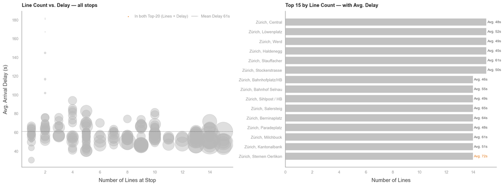

|  | Stop | Linien | Avg. Delay (s) | N Obs |
| --- | --- | --- | --- | --- |
| 0 | Zürich, Haldenegg | 15 | 44.50 | 1018300 |
| 1 | Zürich, Central | 15 | 48.30 | 1570105 |
| 2 | Zürich, Werd | 15 | 49.20 | 570956 |
| 3 | Zürich, Stockerstrasse | 15 | 49.80 | 1071698 |
| 4 | Zürich, Stauffacher | 15 | 60.70 | 1456054 |
| 5 | Zürich, Löwenplatz | 15 | 52.00 | 590617 |
| 6 | Zürich, Kantonalbank | 14 | 51.10 | 1096921 |
| 7 | Zürich, Bellevue | 14 | 55.00 | 1846395 |
| 8 | Zürich, Sternen Oerlikon | 14 | 71.50 | 829204 |
| 9 | Zürich, Paradeplatz | 14 | 48.20 | 1883640 |
| 10 | Zürich, Sihlpost / HB | 14 | 48.90 | 603034 |
| 11 | Zürich, Hirschwiesenstrasse | 14 | 56.10 | 562392 |
| 12 | Zürich, Bahnhofplatz/HB | 14 | 45.70 | 713206 |
| 13 | Zürich, Salersteig | 14 | 64.90 | 556453 |
| 14 | Zürich, Milchbuck | 14 | 61.50 | 1086944 |

```python
an.plot_lines_density_vs_delay(lf_delay, cfg)
show_df(an.table_lines_density_vs_delay(lf_delay))
```

**Beobachtung:** **Kein Overlap zwischen den beiden Top-20-Listen** — exakt 0 Haltestellen erscheinen gleichzeitig in Top-20 nach Linienanzahl UND Top-20 nach Delay.

| Haltestelle | Linien | Ø Delay (s) |
| --- | --- | --- |
| Haldenegg | 15 | **44.5** |
| Werd | 15 | 49.2 |
| Central | 15 | **48.3** |
| Stockerstrasse | 15 | 49.8 |
| Paradeplatz | 14 | **48.2** |
| Stauffacher | 15 | 60.7 |
| Bellevue | 14 | 55.0 |

**Kernbefund:** Die meistbediente Haltestelle Haldenegg (15 Linien) hat 44.5s Ø Delay — das liegt deutlich unter dem Netzschnitt (~56s). Paradeplatz (14 Linien, 48.2s), Central (15 Linien, 48.3s) — allesamt unter Durchschnitt. Einzig Stauffacher (15 Linien, 60.7s) liegt leicht über Durchschnitt.

→ Linienanzahl als Feature wenig vielversprechend für Delay-Prognose; besser: absolute Haltestelleneigenschaften (Korridor, Aussenlage) nutzen.

## Starthaltestellen-Diagnose

Starthaltestellen verzerren die Statistik: Trams warten am Startpunkt auf ihren Abfahrtszeitpunkt und "ankommen" weit vor dem Fahrplan — obwohl das kein echtes Betriebsproblem ist. Das zieht den Ø `arrival_delay` künstlich nach unten und beschönigt die Netz-Performance.

**Identifikation ohne stop_sequence:** Proxy-Kriterium — Starthaltestellen haben:

1. Sehr negatives `arrival_delay` (Tram steht schon lange da)
2. Positives `delay_delta` (Tram wartet, dann Abfahrt nahe Fahrplan → delta = dep_delay − arr_delay ist stark positiv)

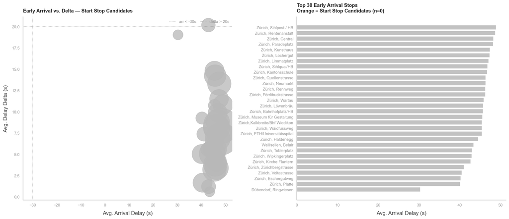

```
Gesamtstatistik:
  Ø arrival_delay ALLE Halte:                 +56.3s
  Ø arrival_delay OHNE 0 Starthaltestellen:  +56.3s
  Verzerrung durch Starthaltestellen:          -0.0s

Starthaltestellen-Kandidaten (0 Stück):
```

|  | Halt | Ø Arr | Ø Dep | Ø Delta | n |
| --- | --- | --- | --- | --- | --- |

```python
an.plot_start_stop_diagnosis(lf_delay, cfg)
show_df(an.table_start_stop_candidates(lf_delay))
```

**Beobachtung:** Die Starthaltestellen-Diagnose findet mit den gewählten Schwellenwerten (avg_arr < −30s UND avg_delta > +20s) **0 Kandidaten**. Die Verzerrung des Netzschnitts durch klassische Starthaltestellen beträgt **0.0s** — kein Bereinigungsbedarf mit dieser Methode.

→ Starthaltestellen-Flag nicht als Feature sinnvoll (keine Kandidaten gefunden). Stattdessen `n_threshold` Filter für Low-Volume-Haltestellen in Modellierung einbauen.

## District Analysis

Average delay per Zurich district (Kreis 1–12 + outside). Identifies spatial delay clusters.

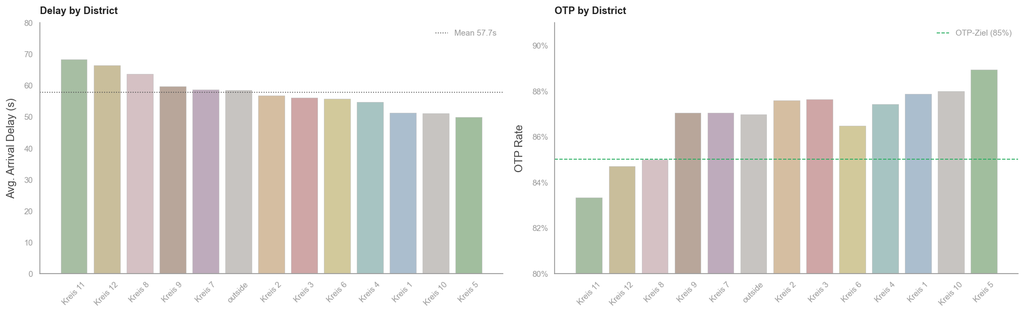

|  | Kreis | Ø Delay | OTP | n Stops |
| --- | --- | --- | --- | --- |
| 0 | Kreis 11 | 68.33 | 0.83 | 5636928 |
| 1 | Kreis 12 | 66.30 | 0.85 | 4105968 |
| 2 | Kreis 8 | 63.68 | 0.85 | 3661568 |
| 3 | Kreis 9 | 59.65 | 0.87 | 4264414 |
| 4 | Kreis 7 | 58.72 | 0.87 | 5688419 |
| 5 | outside | 58.42 | 0.87 | 5677731 |
| 6 | Kreis 2 | 56.71 | 0.88 | 5829771 |
| 7 | Kreis 3 | 55.98 | 0.88 | 4992739 |
| 8 | Kreis 6 | 55.66 | 0.86 | 12619258 |
| 9 | Kreis 4 | 54.72 | 0.87 | 7549226 |
| 10 | Kreis 1 | 51.31 | 0.88 | 18354274 |
| 11 | Kreis 10 | 51.04 | 0.88 | 2567332 |
| 12 | Kreis 5 | 49.92 | 0.89 | 8767273 |

```python
an.plot_district_analysis(lf_delay, cfg,ylim_delay=(0,80), ylim_otp=(0.80, 0.91))
show_df(an.table_district_analysis(lf_delay))
```

**Beobachtung:** Die Stadtkreis-Analyse zeigt ein klares Muster: **Aussenkreise haben höhere Verspätung als Innenstadt**.

**Ø Delay nach Stadtkreis (sortiert):**

| Stadtkreis | Ø Delay (s) | OTP | Charakter |
| --- | --- | --- | --- |
| **Kreis 11** | **68.3** | 83% | Oerlikon/Schwamendingen — langer Aussenkorridor |
| Kreis 12 | 66.3 | 85% | Schwamendingen — nordöstlicher Aussenbereich |
| Kreis 8 | 63.7 | 85% | Seefeld/Balgrist — langer Korridor L2/L4 |
| Kreis 9 | 59.7 | 87% | Altstetten — westlicher Aussenkorridor |
| Kreis 1 | 51.3 | 88% | Altstadt/Innenstadt — kurze Wege, gut koordiniert |
| **Kreis 5** | **49.9** | **89%** | Industriequartier — pünktlichster Kreis |

**Cross-Reference Events & Meteo — drei verschiedene Problemmuster:**

Die schlechten Kreise im räumlichen Kontext (K11, K12, K8) sind **nicht** dieselben wie die Event- oder Wetter-Hotspots:

| Dimension | Betroffene Kreise | Ursache |
| --- | --- | --- |
| **Struktureller Delay** (spatial) | K11, K12, K8, K9 | Lange Aussenkorridore, Delay-Akkumulation |
| **Schnee-sensitiv** (meteo) | K10, K4, K12 | Erhöhte Lage, exponiert |
| **Regen-sensitiv** (meteo) | K5, K9 | Limmat-Niederung, Drainage |
| **Event-sensitiv** (events) | K9, K2, K4 | Hauptbahnhof, Letzigrund, Innenstadt |

**Kernbefund:** Kaum Überschneidung zwischen den drei Mustern. K11 und K8 sind strukturell die schlechtesten Kreise — werden aber weder von Events noch von Wetter besonders getroffen. K5 ist der pünktlichste Kreis (Basis), aber Regen-Hotspot Nr. 1. Das zeigt: struktureller Delay und wetter-/event-bedingter Delay sind weitgehend unabhängige Probleme.

→ `district_nr` als Feature additiv zu `line_name` nützlich; Kreise 11/12 als High-Risk-Marker für strukturellen Delay.

## Line Analysis

Delay profile per tram line — which lines are most unreliable?

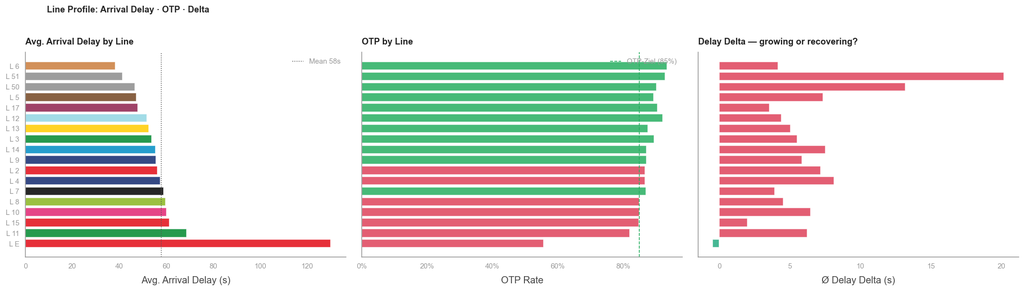

|  | Line | Ø Delay | OTP | Ø Delta | n |
| --- | --- | --- | --- | --- | --- |
| 0 | E | 130.16 | 0.56 | -0.48 | 2511 |
| 1 | 11 | 68.74 | 0.82 | 6.24 | 8979877 |
| 2 | 15 | 61.36 | 0.85 | 1.98 | 2138416 |
| 3 | 10 | 60.05 | 0.85 | 6.48 | 6516391 |
| 4 | 8 | 59.71 | 0.85 | 4.53 | 6267234 |
| 5 | 7 | 58.85 | 0.87 | 3.92 | 8125792 |
| 6 | 4 | 57.44 | 0.87 | 8.11 | 6808772 |
| 7 | 2 | 56.18 | 0.87 | 7.19 | 8147118 |
| 8 | 9 | 55.62 | 0.87 | 5.86 | 8210815 |
| 9 | 14 | 55.52 | 0.87 | 7.52 | 7024821 |
| 10 | 3 | 53.90 | 0.90 | 5.51 | 5202425 |
| 11 | 13 | 52.58 | 0.88 | 5.04 | 8256404 |
| 12 | 12 | 51.78 | 0.92 | 4.39 | 2396392 |
| 13 | 17 | 47.93 | 0.91 | 3.56 | 4635968 |
| 14 | 5 | 47.37 | 0.89 | 7.34 | 3064076 |
| 15 | 50 | 46.58 | 0.90 | 13.17 | 147111 |
| 16 | 51 | 41.35 | 0.93 | 20.18 | 120208 |
| 17 | 6 | 38.40 | 0.93 | 4.15 | 3670570 |

```python
an.plot_line_analysis(lf_delay, cfg)
show_df(an.table_line_analysis(lf_delay))
```

**Linien-Ranking (Ø Arrival Delay):**

| Linie | Ø Delay (s) | OTP | Ø Delta (s) |
| --- | --- | --- | --- |
| E | 130.2 | 56% | −0.5 |
| **L11** | **68.7** | 82% | +6.2 |
| L15 | 61.4 | 85% | +2.0 |
| L10 | 60.1 | 85% | +6.5 |
| L8 | 59.7 | 85% | +4.5 |
| L6 | 38.4 | 93% | +4.2 |
| L51 | 41.4 | 93% | +20.2 |

**Linie E** (OTP 56%, Ø 130s): Sonderlinie/Entlastungslinie — bestätigt F-TARGET-12 und F-NET-08, kein Datenfehler.

→ `line_name` ist stärkster räumlicher Prädiktor. L11 als Hochrisiko-Linie für Modellpriorisierung.

## Feature: `dwell_time`

Geplante Haltezeit = `departure_schedule − arrival_schedule` in Sekunden (F-TARGET-04). Kurze Dwell-Time = wenig Puffer → höheres Verspätungsrisiko (F-TARGET-03). Zeigt welche Haltestellen und Linien strukturell zu wenig Zeit einplanen.

```
dwell_time aus Feature-File geladen
```

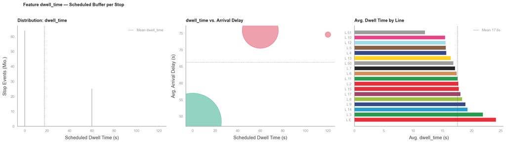

```
Ø dwell_time netzweit: 17.6s
Anteil mit dwell_time ≤ 20s: 71.3%
Anteil mit dwell_time = 0s:  71.3%
```

| Line | Ø Haltezeit (s) | Median Haltezeit (s) | Ø Arr Delay (s) | N Halte |
| --- | --- | --- | --- | --- |
| 51 | 12.10 | 0.00 | 41.40 | 120,208 |
| 10 | 15.50 | 0.00 | 60.00 | 6,516,352 |
| 12 | 15.60 | 0.00 | 51.80 | 2,396,392 |
| 5 | 15.60 | 0.00 | 47.40 | 3,064,057 |
| 4 | 15.70 | 0.00 | 57.40 | 6,807,737 |
| 13 | 16.50 | 0.00 | 52.60 | 8,254,674 |
| 50 | 16.90 | 0.00 | 46.60 | 147,111 |
| 7 | 17.20 | 0.00 | 58.90 | 8,125,785 |
| 6 | 17.50 | 0.00 | 38.40 | 3,670,559 |
| 11 | 17.60 | 0.00 | 68.70 | 8,979,732 |
| 2 | 17.80 | 0.00 | 56.20 | 8,147,112 |
| 15 | 17.80 | 0.00 | 61.40 | 2,138,399 |
| 17 | 18.10 | 0.00 | 47.90 | 4,625,089 |
| 8 | 18.40 | 0.00 | 59.70 | 6,267,228 |
| 9 | 19.00 | 0.00 | 55.60 | 8,210,807 |
| 14 | 19.30 | 0.00 | 55.50 | 7,024,604 |
| 3 | 21.90 | 0.00 | 53.90 | 5,202,405 |
| E | 24.20 | 0.00 | 130.20 | 2,511 |

```python
an.plot_dwell_time(lf_delay, cfg)
show_df(an.table_dwell_time_by_line(lf_delay))
```

**Beobachtung:** Die `dwell_time`-Verteilung zeigt ein überraschendes Ergebnis: **71.3% aller Halte haben dwell_time = 0s** — identisch mit dem ≤20s-Anteil.

**Ø dwell_time netzweit: 17.6s | Anteil 0s: 71.3%**

Das bedeutet: **Mehr als 2 von 3 Halten sind fahrplanmässig als Durchfahrten ohne geplante Haltezeit kodiert.** Der Median ist für alle Linien **0s**.

**Konsequenz für Feature-Nutzung:** Ein Scatter `dwell_time × delay` kann keinen negativen Zusammenhang zeigen, wenn 71% der Datenpunkte bei 0s liegen — die Streuung fehlt. `dwell_time` als kontinuierliches Feature ist damit nur für die 29% der Halte mit geplanter Haltezeit informativ. Als binäres Feature (`has_dwell = dwell_time > 0`) möglicherweise nützlicher.

**Linien-Unterschiede:** Die Ø-Werte variieren zwischen L51 (12.1s) und Linie E (24.2s) — aber alle haben Median=0. L3 hat mit 21.9s die höchste mittlere Haltezeit unter den regulären Hauptlinien, L10 die niedrigste (15.5s).

→ `dwell_time` als Feature weniger stark als erhofft. Stattdessen `has_dwell` (binary) prüfen.

**Hypothese: 10s Puffer pro Halt würde das System deutlich entlasten**

Das positive Delay-Delta (+5–6s pro Halt bei L10/L11) zeigt: Trams akkumulieren Verspätung schrittweise, weil kein Puffer zum Nachholen da ist. Selbst **10s geplante dwell_time an Zwischenhalten** würden dem Fahrer die Möglichkeit geben, kleinere Verzögerungen aufzufangen — ohne den Takt zu sprengen.

Zum Vergleich: Andere Netze (London TfL, Berlin BVG) planen explizite "recovery time" an Knoten (3–5 min an Endpunkten, ~30s an Zwischenhalten). Zürich VBZ verzichtet bewusst darauf zugunsten eines dichteren Takts (5–7 min). Der Preis: jede Störung pflanzt sich fort, da es keine Puffer-Haltestellen gibt.

→ Nicht im Modell direkt lösbar — aber ein starkes Präsentationsargument: *das System ist so eng getaktet, dass strukturell kein Raum zum Nachholen bleibt.*

## Stop Delay Map

Wo liegen die Delay-Hotspots im Stadtgebiet? Haltestellen eingefärbt nach Ø Arrival Delay — Stadtkreise als Hintergrund-Choropleth. Nur Haltestellen mit n ≥ 5000 (statistisch belastbar).

```python
an.plot_stop_delay_map(lf_clean)
show_df(an.table_stop_delay_map(lf_clean))
```

[output not shown]

| Rang | Stop | Kreis | Avg. Delay (s) | OTP | N |
| --- | --- | --- | --- | --- | --- |
| 1 | Zürich, Friedrichstrasse | 12 | 144.60 | 56.7% | 14,357 |
| 2 | Zürich, Friedhof Enzenbühl | 8 | 131.00 | 56.3% | 146,240 |
| 3 | Zürich, Frohburg | 12 | 116.60 | 67.7% | 14,368 |
| 4 | Zürich, Albisgütli | 3 | 101.80 | 65.6% | 13,991 |
| 5 | Zürich, Seebacherplatz | 11 | 99.60 | 68.4% | 147,017 |
| 6 | Zürich, Butzenstrasse | 2 | 98.30 | 69.1% | 155,742 |
| 7 | Zürich, Mattenhof | 12 | 97.50 | 69.8% | 142,064 |
| 8 | Zürich, Altried | 12 | 97.00 | 69.8% | 139,516 |
| 9 | Zürich, Fellenbergstrasse | 9 | 94.70 | 71.1% | 141,837 |
| 10 | Zürich, Strassenverkehrsamt | 3 | 92.50 | 70.2% | 161,957 |
| 11 | Zürich, Würzgraben | 9 | 85.50 | 73.3% | 140,188 |
| 12 | Zürich, Balgrist | 8 | 85.30 | 77.0% | 291,848 |
| 13 | Zürich, Fernsehstudio | 0 | 84.50 | 77.2% | 296,798 |
| 14 | Zürich, Hölderlinstrasse | 7 | 83.60 | 76.0% | 282,359 |
| 15 | Zürich, Leutschenbach | 11 | 83.40 | 78.8% | 534,708 |
| 16 | Zürich, Wetlistrasse | 7 | 83.20 | 76.9% | 291,102 |
| 17 | Schlieren, Zentrum/Bahnhof | 0 | 82.00 | 74.4% | 145,919 |
| 18 | Zürich, Burgwies | 7 | 81.50 | 77.8% | 289,896 |
| 19 | Zürich, Wildbachstrasse | 8 | 80.20 | 75.4% | 280,733 |
| 20 | Zürich, Messe/Hallenstadion | 11 | 79.60 | 79.3% | 281,222 |

**Beobachtung:** Die Karte zeigt ein klares Muster: **Delay-Hotspots liegen an den Aussenkorridoren**, nicht im Innenstadtkern.

**Räumliche Cluster:**

- **Nordost-Korridor** (Kreis 11/12 — Oerlikon, Schwamendingen, Leutschenbach): durchgehend hohe Delays, konsistent mit F-SPAT-03
- **Seefeld-Korridor** (Kreis 8 — Balgrist, Burgwies): lange Strecke L2/L4 ohne Puffer
- **Innenstadt** (Kreis 1/5): auffällig niedrige Delays — kurze Segmente, gut koordiniert

**Endstationen-Muster:** Viele der roten Bubbles liegen erkennbar an oder kurz vor den Linienendhaltestellen — der akkumulierte Delay entlädt sich am Terminus. Bei einigen Linien (L11, L7) sieht man die Verzögerung schon 1–2 Haltestellen vor dem Ende ansteigen; ein kontinuierlicher Aufbau über die gesamte Strecke ist seltener.

**Graue Netzpunkte als Referenz:** Die Innenstadthalte (graue Punkte dicht gedrängt) zeigen kaum farbige Überlagerung — Bestätigung dass der Kern pünktlicher ist als die Peripherie.

→ Karte bestätigt F-SPAT-01 und F-SPAT-03 visuell. Starkes Präsentationselement.

## Line Delay Map

Haltestellen nach Linie gruppiert — jede Linie eine eigene Farbe, Blasengrösse = Ø Delay. Linien einzeln an- und abwählbar in der Legende.

```python
an.plot_line_delay_map(lf_clean, cfg)
```

[output not shown]

**Beobachtung:** Die Linien-Karte macht die unterschiedliche Streckencharakteristik sofort sichtbar — jede Farbe erzählt eine eigene Geschichte.

**Auffällige Linien:**

- **L11 / L13 / L7:** Grosse Bubbles an Start und Ende der Linie, kaum in der Mitte. Klassisches Akkumulationsmuster: Delay baut sich entlang der Strecke auf und entlädt sich am Terminus. Startstationen zeigen ebenfalls grosse Bubbles — Rückfahrten starten bereits mit Verspätung wenn die Hinfahrt zu spät ankam.
- **L6 / L51:** Kleine, gleichmässige Bubbles entlang der gesamten Strecke — kurze Linien mit wenig Akkumulationspotenzial.
- **L2 / L4:** Mittlere Bubbles, aber Hotspot klar im Seefeld-Korridor (Balgrist/Burgwies).

**Kernbefund:** Das Endstationen-Muster bei L11/L13/L7 ist ein eigenständiger Finding — lange Linien ohne Puffer akkumulieren Delay systematisch, der Endhalt trägt die Last der gesamten Strecke. Kurze Linien (L6) sind strukturell pünktlicher, unabhängig vom Korridor.

→ Linienlänge als Proxy-Feature für Delay-Risiko prüfen (F-SPAT-09 neu).

## Linien-Delay nach Uhrzeit — Heatmap

Linie × Stunde als Heatmap — zeigt wann welche Linie am meisten leidet und ob das Muster linienspezifisch ist oder netzweit synchron verläuft.

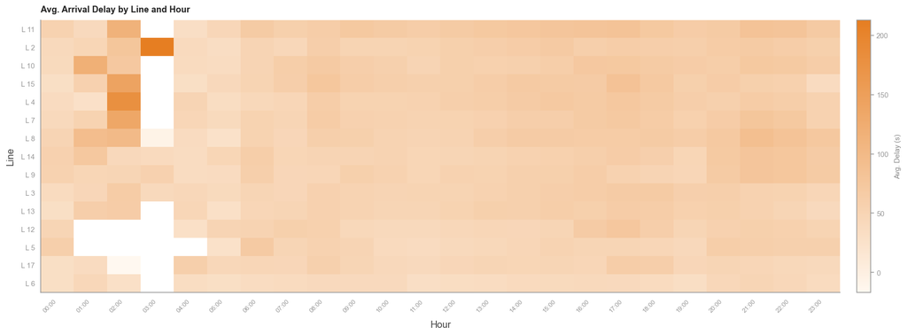

| Line | Ø Delay gesamt (s) | Peak-Stunde | Peak-Delay (s) | Nacht-Min (s) |
| --- | --- | --- | --- | --- |
| 11 | 67.90 | 02:00 | 113.30 | 31.50 |
| 2 | 63.00 | 03:00 | 213.00 | 38.70 |
| 10 | 62.00 | 01:00 | 118.40 | 37.20 |
| 15 | 61.70 | 02:00 | 142.50 | 30.50 |
| 4 | 61.00 | 02:00 | 178.00 | 27.30 |
| 7 | 60.80 | 02:00 | 135.30 | 40.70 |
| 8 | 59.80 | 02:00 | 98.40 | -7.80 |
| 14 | 55.20 | 21:00 | 77.50 | 35.30 |
| 9 | 54.70 | 21:00 | 78.10 | 34.90 |
| 3 | 52.80 | 18:00 | 67.70 | 37.70 |
| 13 | 52.20 | 17:00 | 64.80 | 30.00 |
| 12 | 51.20 | 17:00 | 73.80 | 28.60 |
| 5 | 49.40 | 06:00 | 69.10 | 59.90 |
| 17 | 44.20 | 17:00 | 62.30 | -16.90 |
| 6 | 37.50 | 21:00 | 48.70 | 28.40 |

```python
an.plot_line_hour_heatmap(lf_clean, cfg)
show_df(an.table_line_hour_heatmap(lf_clean))
```

**Beobachtung:** Die Heatmap zeigt zwei überlagerte Muster — ein netzweites und ein linienspezifisches.

**Frühe Morgenstunden (6–8 Uhr):** Bereits deutlicher Delay-Anstieg, bevor der volle Berufsverkehr beginnt — das System startet nicht mit "Null" in den Tag.

→ `hour` als Feature bestätigt (temporal Notebook), aber Interaktion `hour × line_name` wäre stärker als beide Features einzeln.

## Stop Delay nach Fahrtrichtung

Gleiche Linie, zwei Richtungen nebeneinander — zeigt ob Delay symmetrisch ist oder eine Fahrtrichtung deutlich schlechter. Richtung = letzter Halt des Trips (aus `trip_id` abgeleitet).

```python
# L11 als Beispiel — schlechteste reguläre Linie

an.plot_stop_delay_by_direction(lf_clean, line_name="11")

show_df(an.table_stop_delay_by_direction(lf_clean, line_name="11"))

# Weitere Linien nach Bedarf:
# an.plot_stop_delay_by_direction(lf_clean, line_name="9")
# an.plot_stop_delay_by_direction(lf_clean, line_name="8")
```

[output not shown]

|  | Richtung | Stop | Avg. Delay (s) | Ø Stop-Seq | N |
| --- | --- | --- | --- | --- | --- |
| 0 | Friedhof Enzenbühl | Zürich, Friedhof Enzenbühl | 131.22 | 29.27 | 140146 |
| 1 | Friedhof Enzenbühl | Zürich, Wetlistrasse | 123.75 | 26.36 | 139606 |
| 2 | Friedhof Enzenbühl | Zürich, Burgwies | 121.81 | 27.29 | 139446 |
| 3 | Friedhof Enzenbühl | Zürich, Balgrist | 121.09 | 28.27 | 140299 |
| 4 | Friedhof Enzenbühl | Zürich, Klusplatz A | 115.40 | 2.00 | 588 |
| 5 | Friedhof Enzenbühl | Zürich, Signaustrasse | 107.38 | 23.97 | 132480 |
| 6 | Friedhof Enzenbühl | Zürich, Hegibachplatz B | 103.74 | 24.85 | 137561 |
| 7 | Friedhof Enzenbühl | Zürich, Hedwigsteig | 102.71 | 25.83 | 131962 |
| 8 | Friedhof Enzenbühl | Zürich, Kreuzplatz | 93.99 | 23.84 | 122065 |
| 9 | Friedhof Enzenbühl | Zürich, Sihlstrasse | 74.15 | 2.06 | 1743 |
| 10 | Fernsehstudio | Zürich, Leutschenbach | 124.60 | 27.70 | 135237 |
| 11 | Fernsehstudio | Zürich, Oerlikerhus | 121.47 | 27.40 | 142293 |
| 12 | Fernsehstudio | Zürich, Hirschwiesenstrasse | 118.74 | 20.56 | 390 |
| 13 | Fernsehstudio | Zürich, Fernsehstudio | 113.66 | 29.37 | 142504 |
| 14 | Fernsehstudio | Glattpark | 112.02 | 28.38 | 142326 |
| 15 | Fernsehstudio | Zürich, Bahnhof Oerlikon Ost | 110.99 | 24.87 | 269 |
| 16 | Fernsehstudio | Zürich, Messe/Hallenstadion | 109.09 | 26.72 | 135051 |
| 17 | Fernsehstudio | Zürich, Milchbuck | 106.72 | 19.48 | 390 |
| 18 | Fernsehstudio | Zürich, Berninaplatz | 106.50 | 21.49 | 390 |
| 19 | Fernsehstudio | Zürich, Guggachstrasse | 105.76 | 18.50 | 391 |

**Beobachtung:** Die Richtungs-Karte zeigt ob Delay symmetrisch verteilt ist oder eine Fahrtrichtung systematisch schlechter ist.

**Asymmetrie als Befund:** Wenn beide Richtungen gleich wären, wäre die Karte spiegelbildlich. Abweichungen zeigen wo das Netz unidirektionale Probleme hat — z.B. weil eine Richtung mehr Halt-Interaktionen mit dem MIV hat oder die Streckenführung ungünstiger ist.

→ Richtung als Feature prüfen (`trip_direction` = letzter Stop). Weitere Linien mit `an.plot_stop_delay_by_direction(lf_clean, line_name="9")` etc. analysierbar.

## Delay-Profil alle Tramlinien — interaktiv

Alle Tramlinien auf einer Karte — **Farbe: VBZ-Linienfarbe** (wie bekannt aus dem Netzplan), **Größe: Ø Arrival Delay** (global skaliert, Linien vergleichbar). Linien über die Legende einzeln ein-/ausblenden. Hover zeigt Haltestellenname, Linie, Ø Delay, % kein Puffer.

`min_n=1000` filtert Baustellen-Kurzläufer automatisch heraus (L6 hat 230+ Routenvarianten aus dem Zeitraum 2023–2025 — Kurzläufer-Endhalte haben n < 1000 und werden ausgeblendet).

```python
an.plot_line_delay_profile_map(lf_clean, cfg=cfg)
```

[output not shown]

**Beobachtungen zur Delay-Profil-Karte — Linien im Vergleich**

**Grundmuster: Grosse Bubbles an den Streckenenden, kleine Bubbles in der Mitte**

Über alle Linien hinweg zeigen die Stops mit den grössten Delay-Kreisen ein konsistentes Muster: sie liegen am äusseren Ende der jeweiligen Linie, nicht in der Mitte oder im Stadtzentrum. Statistische Prüfung bestätigt das: Alle Outlier-Stops (>1.5σ über Linienmittel) liegen maximal 31m von der GTFS-Shape entfernt — sie sind physisch **auf** der Strecke, nicht daneben. Die Ursache ist der **Akkumulationseffekt**: Verspätungen bauen sich entlang des Fahrwegs auf. Wer am äusseren Terminus ankommt, trägt die Last der ganzen Fahrt.

Ausgewählte Linien-Beobachtungen:

- **L11** — Enzenbühl, Balgrist, Wetlistrasse, Burgwies als Spitzenreiter. Alles äussere Endpunkte Richtung Tiefenbrunnen/Hirslanden. Pearson r ≥ 0.85 in der Kaskadenanalyse (→ unten) bestätigt: Delay baut sich Trip für Trip auf.
- **L10** — Auffälliger Stop nur am nördlichen Ende (Salersteig/Leutschenbach). Richtung Zentrum sind die Stops unauffällig.
- **L14** — Zwei Stops auffällig: Seebacherplatz (71s, stärkster Outlier) und Milchbuck (65s). Beide am nördlichen Streckenende in Seebach. Der Rest der Linie liegt nahe am Linienmittel (55s).
- **L8** — Römerhof, Hölderlinstrasse, Englischviertelstrasse am Zürichberg-Ende erhöht. Entspricht dem Seefeld/Balgrist-Korridor (K8).

**L17 — Zwei Strecken-Cluster sichtbar**

Die L17 erscheint auf der Karte in zwei räumlich getrennten Gruppen: eine entlang des primären Korridors (Werdhölzli → Hardhof → Hardturm → Bahnhofquai/HB, ~88k Ereignisse/Jahr) und eine zweite Gruppe südlich davon (Bahnhofstrasse → Paradeplatz → Tunnelstrasse → Bahnhof Enge → Uetlihof → Strassenverkehrsamt, ~13–17k Ereignisse/Jahr). **Das ist kein Datenfehler.** Die L17 bedient beide Streckenäste — ein Teil der Kurse endet am HB, ein anderer fährt weiter via Innenstadt zum Uetlihof. Beide Gruppen liegen über der 5%-Schwelle und erscheinen deshalb auf der Karte. Der Strassenverkehrsamt-Halt (75s) ist dabei der auffälligste Outlier dieses Asts.

**L18 — fehlt in der Karte**

Die Liniennummer `18` kommt im VBZ IST-Datensatz nicht vor. L18 war eine temporäre Baustellenlinie (→ `02_preparation.ipynb` Bereinigungsstrategie) und ist entweder ausserhalb des erfassten Zeitraums betrieben worden oder unter einer anderen Bezeichnung erfasst. Die Karte zeigt automatisch nur Linien, die im Datensatz vorhanden sind.

### Wo hat der Fahrplan Puffer? — Dwell Time Profil

Gleiche Karte, anderes Signal: **Farbe = Ø Dwell Time** (geplante Haltezeit je Haltestelle). Rot = kein Puffer (0 s) · Orange = wenig Puffer (~ 15 s) · Grün = guter Puffer (≥ 30 s). Bubble-Größe einheitlich — das Signal liegt ausschließlich in der Farbe.

**Vergleich mit Delay-Karte oben:** Haltestellen rot in beiden Karten = kein Puffer **und** hohe Verspätung → strukturelles Bottleneck. Haltestellen grün in der Dwell-Karte = Fahrplan hat hier bewusst Puffer eingebaut.

```python
an.plot_line_dwell_profile_map(lf_clean, cfg=cfg)
```

[output not shown]

**Detailansicht: L11 vs. L6** — einzelne Linie mit Delay-Farbskala für genauere Analyse. `plot_stop_dwell_map` zeigt eine Linie mit Delay-Gradient (grün → rot).

```python
an.plot_stop_dwell_map(lf_clean, line_name="11", cfg=cfg)
an.plot_stop_dwell_map(lf_clean, line_name="6", cfg=cfg)
```

[output not shown]

## Interaktive Linienansicht — Kritische Streckenabschnitte

Wo auf der Linie beginnt das Problem?

GTFS-Gleisgeometrie als Routen-Linie, Haltestellen nach Ø Arrival Delay eingefärbt (grün → amber → rot). Top-3 Problemstops annotiert. Linie wählbar über `line_name`-Parameter.

```python
an.plot_line_route_map(lf_clean, line_name="11")
show_df(an.table_line_route_map(lf_clean, line_name="11"))
```

[output not shown]

| Stop | Avg. Delay (s) | OTP (%) | Ø Stop-Seq | N |
| --- | --- | --- | --- | --- |
| Friedhof Enzenbühl | 131.10 | 56.30 | 29.20 | 140293 |
| Fernsehstudio | 113.60 | 62.20 | 29.30 | 142613 |
| Leutschenbach | 94.20 | 74.90 | 15.60 | 276269 |
| Balgrist | 85.40 | 76.90 | 15.20 | 279984 |
| Sternen Oerlikon | 85.20 | 77.50 | 16.00 | 268181 |
| Wetlistrasse | 83.70 | 76.80 | 15.20 | 279262 |
| Burgwies | 81.80 | 77.70 | 15.20 | 278070 |
| Messe/Hallenstadion | 79.30 | 79.50 | 15.60 | 275830 |
| Bahnhof Oerlikon | 79.00 | 79.50 | 16.00 | 273888 |
| Glattpark | 78.40 | 79.60 | 15.30 | 282964 |
| Oerlikerhus | 77.90 | 77.70 | 15.30 | 283156 |
| Hedwigsteig | 77.90 | 81.30 | 15.10 | 272308 |
| Signaustrasse | 73.50 | 80.30 | 15.30 | 268397 |
| Regensbergbrücke | 73.40 | 82.20 | 15.80 | 277147 |
| Hegibachplatz B | 70.30 | 81.60 | 15.60 | 269464 |
| Bad Allenmoos | 70.00 | 83.00 | 15.80 | 277161 |
| Kreuzplatz | 65.80 | 82.80 | 15.30 | 262643 |
| Kronenstrasse | 65.60 | 83.60 | 15.80 | 262754 |
| Brunnenhof | 62.90 | 85.00 | 15.90 | 276287 |
| Bahnhofstrasse/HB | 61.90 | 84.40 | 15.90 | 257597 |
| Schaffhauserplatz | 60.80 | 85.00 | 15.80 | 277534 |
| Beckenhof | 60.00 | 85.40 | 15.80 | 263144 |
| Bürkliplatz | 58.10 | 84.40 | 15.50 | 271421 |
| Bahnhof Stadelhofen | 57.90 | 84.80 | 15.70 | 258702 |
| Bucheggplatz D | 57.70 | 85.40 | 16.10 | 263270 |
| Laubiweg | 57.00 | 86.00 | 15.80 | 275957 |
| Stampfenbachplatz | 56.40 | 85.60 | 15.90 | 262412 |
| Bellevue | 56.20 | 84.90 | 15.80 | 278115 |
| Kantonalbank | 52.50 | 87.20 | 15.50 | 272054 |
| Bahnhofquai/HB | 52.00 | 85.80 | 15.90 | 260858 |
| Paradeplatz | 51.70 | 86.40 | 15.50 | 272863 |
| Rennweg | 50.60 | 87.10 | 15.70 | 263846 |
| Central | 48.20 | 77.60 | 15.40 | 14850 |
| Röslistrasse | 36.90 | 81.30 | 14.40 | 14826 |
| Sonneggstrasse | 35.10 | 80.70 | 14.40 | 14810 |
| Ottikerstrasse | 29.80 | 82.20 | 14.40 | 14820 |

## Situationsvergleich — gleiche Linie, verschiedene Kontexte

Jeder Kontext ist ein eigener Trace — über die Legende ein-/ausblendbar. Zeigt warum ein pauschaler Fahrplan-Puffer nicht ausreicht: Schnee, Events und Rush-Hour betreffen verschiedene Stops (F-REC-03). Grundlage für kontextsensitive Fahrpläne.

```python
an.plot_line_context_map(lf_clean, line_name="11")
show_df(an.table_line_context_map(lf_clean, line_name="11"))
```

[output not shown]

| Stop | Normal | Snow | Event | Rush | Spätnacht |
| --- | --- | --- | --- | --- | --- |
| Glattpark | nan | 124.20 | 84.10 | 91.00 | 85.50 |
| Bad Allenmoos | nan | 121.90 | 77.40 | 84.20 | 78.20 |
| Bahnhof Enge/Bederstr. | nan | nan | 55.50 | nan | 55.60 |
| Bahnhof Oerlikon | nan | 136.90 | 89.80 | 73.10 | 107.30 |
| Bahnhof Stadelhofen | nan | 105.70 | 57.90 | 59.90 | 69.90 |
| Bahnhofquai/HB | nan | 92.80 | 53.70 | 57.10 | 42.60 |
| Bahnhofstrasse/HB | nan | 104.90 | 62.70 | 59.40 | 67.40 |
| Balgrist | nan | 124.80 | 81.30 | 87.60 | 92.00 |
| Beckenhof | nan | 99.40 | 67.10 | 72.60 | 68.60 |
| Bellevue | nan | 106.30 | 59.40 | 55.60 | 71.00 |
| Brunnenhof | nan | 112.90 | 70.20 | 65.70 | 74.80 |
| Bucheggplatz D | nan | 109.10 | 64.70 | 70.20 | 64.90 |
| Burgwies | nan | 120.60 | 81.30 | 78.70 | 97.10 |
| Bürkliplatz | nan | 100.20 | 60.90 | 52.40 | 74.90 |
| Central | nan | nan | 46.10 | 64.30 | 46.80 |
| Feldeggstrasse | nan | nan | 70.30 | nan | 66.70 |
| Fernsehstudio | nan | 181.40 | 119.60 | 135.80 | 110.80 |
| Friedhof Enzenbühl | nan | 199.70 | 128.80 | 120.10 | 169.50 |
| Fröhlichstrasse | nan | nan | 68.10 | nan | 68.60 |
| Guggachstrasse | nan | nan | 73.40 | nan | nan |
| Haldenegg | nan | nan | 36.20 | 39.70 | 49.50 |
| Hedwigsteig | nan | 113.60 | 75.90 | 71.50 | 91.20 |
| Hegibachplatz B | nan | 103.50 | 60.70 | 69.60 | 63.40 |
| Helmhaus | nan | nan | 38.60 | 53.90 | 40.00 |
| Hottingerplatz | nan | nan | 63.90 | nan | 49.40 |
| Hölderlinstrasse | nan | nan | 119.90 | nan | nan |
| Höschgasse | nan | nan | 71.20 | nan | 68.60 |
| Kantonalbank | nan | 96.70 | 55.30 | 43.00 | 69.50 |
| Kreuzplatz | nan | 104.10 | 60.50 | 63.80 | 68.20 |
| Kreuzstrasse | nan | nan | 75.90 | nan | 66.80 |
| Kronenstrasse | nan | 103.60 | 69.50 | 67.90 | 67.30 |
| Kunsthaus | nan | nan | 65.40 | nan | 50.90 |
| Laubegg | nan | nan | 61.90 | nan | 68.20 |
| Laubiweg | nan | 111.20 | 63.70 | 62.30 | 67.10 |
| Leutschenbach | nan | 144.90 | 101.70 | 98.70 | 111.50 |
| Messe/Hallenstadion | nan | 131.10 | 81.40 | 86.10 | 83.30 |
| Oerlikerhus | nan | 122.80 | 81.60 | 91.20 | 81.80 |
| Opernhaus | nan | nan | 86.70 | nan | 77.50 |
| Ottikerstrasse | nan | nan | 28.90 | 22.60 | 44.30 |
| Paradeplatz | nan | 95.70 | 55.60 | 46.60 | 65.60 |
| Rathaus | nan | nan | 38.40 | 50.40 | 39.00 |
| Regensbergbrücke | nan | 122.50 | 80.00 | 86.00 | 81.20 |
| Rennweg | nan | 93.70 | 53.20 | 40.70 | 66.50 |
| Rudolf-Brun-Brücke | nan | nan | 38.30 | 53.10 | 39.50 |
| Römerhof | nan | nan | 78.30 | nan | 71.60 |
| Röslistrasse | nan | nan | 35.80 | 25.30 | 45.90 |
| Saalsporthalle | nan | nan | 60.40 | nan | 65.70 |
| Schaffhauserplatz | nan | 116.40 | 68.80 | 67.60 | 72.40 |
| Signaustrasse | nan | 105.50 | 62.10 | 73.60 | 65.10 |
| Sihlcity Nord | nan | nan | 67.20 | nan | 71.80 |
| Sihlstrasse | nan | nan | 68.80 | nan | 64.40 |
| Sonneggstrasse | nan | nan | 33.30 | 31.90 | 47.30 |
| Stampfenbachplatz | nan | 93.00 | 57.30 | 68.10 | 41.00 |
| Stauffacher | nan | nan | 67.00 | nan | 64.00 |
| Sternen Oerlikon | nan | 137.90 | 86.40 | 91.90 | 81.30 |
| Stockerstrasse | nan | nan | 58.90 | nan | 71.40 |
| Strassenverkehrsamt | nan | nan | 82.10 | nan | 109.50 |
| Tunnelstrasse | nan | nan | 60.50 | nan | 74.40 |
| Uetlihof | nan | nan | 64.20 | nan | 78.00 |
| Waffenplatzstrasse | nan | nan | 58.50 | nan | 57.90 |
| Werd | nan | nan | 87.30 | nan | 83.70 |
| Wetlistrasse | nan | 121.00 | 83.10 | 80.80 | 98.60 |
| Wildbachstrasse | nan | nan | 121.80 | nan | 110.50 |

## Kaskadenanalyse: Delay-Propagation zwischen Halten

Pearson-Korrelation zwischen Delay(Halt n) und Delay(Halt n+1) innerhalb desselben Trips — misst wie stark sich Verspätung von Halt zu Halt fortpflanzt. Hohe Korrelation = systemischer Kaskadeneffekt.

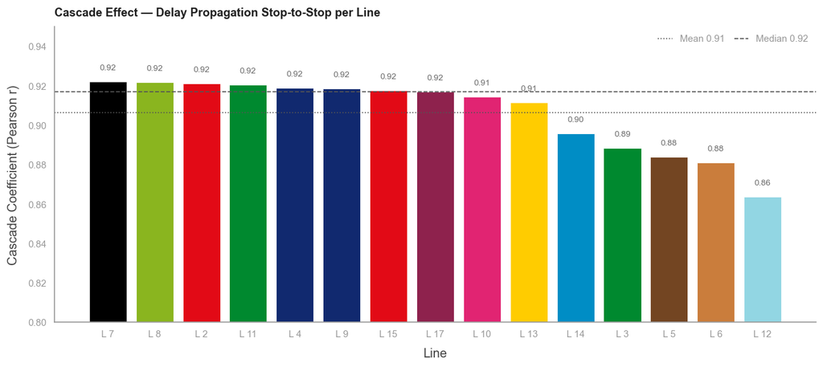

|  | Line | Pearson r | N Halte | Stärke |
| --- | --- | --- | --- | --- |
| 0 | 7 | 0.92 | 7,513,355 | 🔴 Stark |
| 1 | 8 | 0.92 | 5,673,749 | 🔴 Stark |
| 2 | 2 | 0.92 | 7,525,896 | 🔴 Stark |
| 3 | 11 | 0.92 | 8,321,987 | 🔴 Stark |
| 4 | 4 | 0.92 | 6,218,609 | 🔴 Stark |
| 5 | 9 | 0.92 | 7,608,608 | 🔴 Stark |
| 6 | 15 | 0.92 | 1,779,844 | 🔴 Stark |
| 7 | 17 | 0.92 | 4,088,688 | 🔴 Stark |
| 8 | 10 | 0.91 | 5,985,346 | 🔴 Stark |
| 9 | 13 | 0.91 | 7,542,044 | 🔴 Stark |
| 10 | 14 | 0.90 | 6,406,444 | 🔴 Stark |
| 11 | 3 | 0.89 | 4,610,392 | 🔴 Stark |
| 12 | 5 | 0.88 | 2,504,422 | 🔴 Stark |
| 13 | 6 | 0.88 | 3,088,503 | 🔴 Stark |
| 14 | 12 | 0.86 | 2,093,389 | 🔴 Stark |

```python
an.plot_cascade_effect(lf_clean, cfg=cfg, ylim=(0.8, 0.95))
show_df(an.table_cascade_effect(lf_clean))
```

## Key Findings

→ Vollständige Findings-Tabelle mit Impact und Action in `03_analysis_0-overview.ipynb`.

`Präsentation`: **hot** = Kernbefund · **story** = gutes Narrativ · **—** = intern/Feature-Engineering

[output not shown]